# CDF, Probability Integral Transformation, and Random Variable Generation

Author

Jyotishka Datta

Published

August 24, 2026

# 1 Introduction

Simulation is one of the most important tools in modern statistics, machine learning, data science, Bayesian computation, and stochastic modeling. Many statistical procedures rely on our ability to generate random observations from probability distributions whose theoretical properties are already known.

Modern statistical software makes simulation appear effortless. For example, a single call to `rnorm()` generates observations from a Normal distribution and `rexp()` generates observations from an Exponential distribution. However, these functions conceal a large amount of mathematical structure and numerical computation.

The purpose of these notes is to develop the ideas that make random variable generation possible. Along the way we review probability distribution functions, cumulative distribution functions, quantiles, inverse transformations, and several fundamental simulation algorithms.

Understanding these concepts is important because many practical applications require simulation from probability distributions that are not available as built-in functions. Once the underlying principles are understood, new simulation algorithms can be constructed whenever a distribution is specified mathematically.

## 1.1 Learning Objectives

After completing these notes, students should be able to:

# 2 Sampling Random Numbers in R

R provides a large collection of built-in probability distributions. Each distribution is accompanied by four related functions that perform different tasks. A key advantage of R is that the naming convention is remarkably consistent. Once the convention is learned for one distribution, it applies almost universally.

The suffix identifies the distribution itself, whereas the prefix indicates the operation being performed.

| Prefix | Meaning |
| --- | --- |
| d | Density or probability mass function |
| p | Cumulative distribution function |
| q | Quantile (inverse CDF) |
| r | Random generation |

The following distributions are among the most commonly used.

| Distribution | Suffix |
| --- | --- |
| Normal | norm |
| Binomial | binom |
| Poisson | pois |
| Exponential | exp |
| Uniform | unif |
| Student t | t |
| Chi-square | chisq |
| F | f |

For example,

- `dnorm()` evaluates the Normal density.
- `pnorm()` evaluates the Normal CDF.
- `qnorm()` computes Normal quantiles.
- `rnorm()` generates Normal random variables.

Consequently, learning one naming convention provides immediate access to a large family of probability models.

# 3 Probability Distribution Functions

## 3.1 Discrete Random Variables

For a discrete random variable, probability is assigned to individual outcomes. The probability distribution function, often called the probability mass function (PMF), tells us how likely each possible value is.

Mathematically, the PMF is defined as:

$$f(x)=P(X=x).$$

The value of the function at a particular point is an actual probability. Consequently,

$$0 \le f(x) \le 1,$$

and the probabilities across all possible values of the random variable must sum to one. Formally, if a discrete random variable takes the values in a set $\{x_1, x_2, \ldots, x_k \}$, then we must have:

$$\sum_{i=1}^{k} P(X = x_i) = \sum_{i=1}^{k} f(x_i) = 1$$

A common example is the Binomial distribution. If

$$X\sim\text{Binomial}(n,p),$$

then the probability that exactly (x) successes occur is

$$f(x)= \binom{n}{x} p^x(1-p)^{n-x}.$$

The binomial model appears whenever we count the number of successes in a fixed number of independent trials.

We often say that a Binomial random variable gives the number of successes in $n$ tosses of a coin with probability of head $p$. The coin toss is obviously an artifact for any binary experiment where the outcomes can be $0$ and $1$ or “success” and “failure”.

A discrete random variable can also take countably infinite values, e.g., all non-negative integers in the set $\{0, 1, 2, \ldots, \infty\}$. The most prime example is Poisson. A Poisson random variable is typically used to model the number of events that occurs in either a defined space or time or space-and-time, e.g., the number of emails that you receive in your inbox on a given day from 8 to 10 am. It has just one parameter $\lambda$, and the PMF is:

$$P(X = x) = e^{-\lambda} \frac{\lambda^x}{x|}, \quad x \in \{0, 1, 2, \ldots, \infty \}, \quad \lambda \ge 0$$

It is instructive to see that the PMF adds up to 1 over the entire line of non-negative integers.

### 3.1.1 Example

For a Binomial random variable, `pbinom` gives $P(X\le 3).$ The two other parameters are the size $n$ and probability of success $p$.

```r
pbinom(3, size = 5, prob = 0.4)
```

```
[1] 0.91296
```

## 3.2 Continuous Random Variables

Continuous random variables behave differently from discrete random variables.

The first major difference is that, for a continuous variable, the density function $f(x)$ does not directly represent a probability.

For example, $f(23)$ for a Normal density is simply the height of the curve at $x=23$. This distinction is important because probabilities for continuous variables are obtained through areas under the density curve rather than heights of the curve.

In fact, for any single point on the real line:

$$P(X=x)=0 \quad \text{for} \quad x \in \mathbb{R}, \quad \text{where} \; X \; \text{is a continuous r.v.}$$

This is true for every continuous distribution. That is, for a continuous random variable, only intervals have nonzero probability, such as

$$P(a\le X\le b) = \int_{a}^{b} f(x) dx, \; \text{where} \; -\infty < a \le b < \infty.$$

So, what does the density function measure? We need to think analytically to understand this. Let $(a-h, a + h)$ be a infinitessimally small interval of length $2h$. The probability that a continuous random variable belongs to this interval can be calculated as:

$$P(a - h\le X\le a + h) = \int_{a-h}^{a + h} f(x) dx \approx f(a) \times \text{length of the interval} = f(a) \times 2h$$
Similarly, consider another such small interval $(b-h, b + h)$, and the probability $P(b - h\le X\le b + h) \approx f(b) \times 2h$.

Now, if $a$ and $b$ are points on the real line such that $f(a) > f(b)$, then using the above approximation, we can say

$$P(a - h\le X\le a + h) > P(b - h\le X\le b + h)$$

So, it is more probable that $X$ will fall in a tiny interval near $a$ than it will fall in an interval of the same size near $b$, that is, the **relative importance** of the point $a$ is higher than the point $b$. The point where $f(x)$ is highest is called the **mode**: the most probable value.

# 4 Cumulative Distribution Functions

Although density functions are useful for visualizing the shape of a distribution, cumulative distribution functions are often more useful for practical calculations.

The cumulative distribution function (CDF) answers a simple question:

> What is the probability that the random variable is less than or equal to a specified value?

Formally, for any random variable, irrespective of whether it is discrete or continuous, the definition of CDF is:

$$F(x)=P(X\le x).$$

Because probabilities accumulate as we move from left to right, every CDF has the following properties:

1. It never decreases.
2. It is bounded between 0 and 1.
3. It approaches 0 far to the left.
4. It approaches 1 far to the right.

These properties make the CDF one of the most important objects in probability theory. In fact, knowing the CDF completely determines the distribution.

For a discrete random variable,

$$F(x)=\sum_{t\le x} f(t).$$

For a continuous random variable:

$$F(x) = \int_{-\infty}^{x} f(s) ds$$

# 5 Visualizing the CDF

You can use `p` prefix for getting the values of the CDF for named random variables, as mentioned before, and we can use those values to plot. The `p` function can also take whole vectors and return the CDF at each observation.

Here is a small script to plot the Binomial CDF where $n = 30$ and $p = 0.5$.

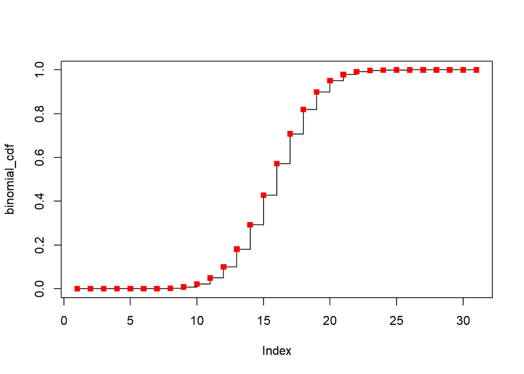

```r
vals <- (0:30)

binomial_cdf <- pbinom(vals, 30, 0.5)
plot(binomial_cdf, type = "s")
points(binomial_cdf, pch = 15, col = "red")
```

Alternatively, we can use the `curve` function in `R` that will take a function as an argument, like we pass on `pnorm` as the first argument here. We plot the normal CDF from $5$ to $35$ where the normal distribution has mean = 20 and standard deviation 4.

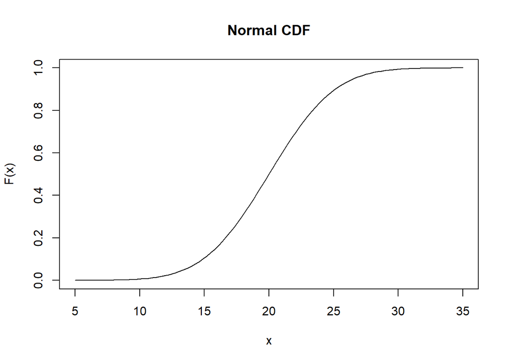

```r
curve(pnorm(x, mean = 20, sd = 4),from = 5, to = 35, xlab = "x", ylab = "F(x)", main = "Normal CDF")
```

Both graphs show the cumulative probability associated with each value of (x). The curve increases from 0 to 1 and never decreases.

# 6 Empirical CDF

In many real applications we do not know the distribution from which our data were generated. Instead, we are given a sample and must infer the underlying distribution.

One approach is to estimate the density using histograms or kernel density estimators. Another is to estimate the cumulative distribution function directly.

The empirical CDF (ECDF) is simply the proportion of observations less than or equal to a given value.

As the sample size grows, the ECDF increasingly resembles the true population CDF. Consequently, the ECDF provides a powerful nonparametric summary of a sample without requiring any distributional assumptions.

Like the theoretical CDF, we can also plot the empirical CDF much in the same way. See the example below: here the step function is an estimate of the unknown population CDF using observed data.

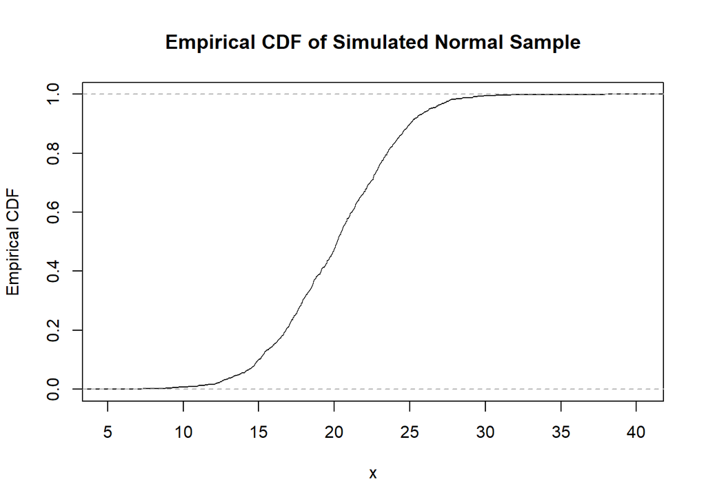

```r
sample1 <- rnorm(1000, mean = 20, sd = 4)

plot(ecdf(sample1), xlab = "x", ylab = "Empirical CDF", main = "Empirical CDF of Simulated Normal Sample"
)
```

# 7 Quantiles and Percentiles

The next concept we need is the quantile. A quantile is the value that cuts off a specified proportion of the distribution.

For example:

- The 50th percentile is the median.
- The 25th percentile is the first quartile.
- The 75th percentile is the third quartile.

The general problem is:

> Find the value (x) such that the probability to its left equals a specified value (p).

Mathematically,

$$P(X\le x)=p.$$

Since

$$F(x)=P(X\le x),$$

the problem becomes solving

$$F(x)=p.$$

The solution is written

$$x=F^{-1}(p),$$

which is why quantiles are often called inverse CDF calculations.

However, a CDF $F$ is only required to be a weakly monotonic and right-continuous function so the inverse of $F$ might not be unique. For example, the CDF for a discrete random variable has jumps at every point of its support. See the Binomial CDF below.

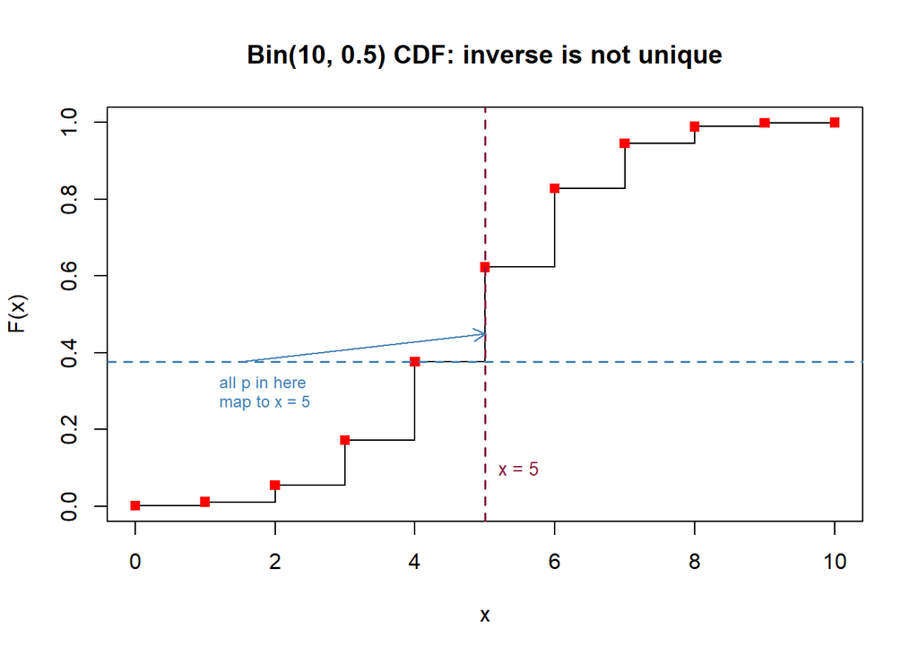

For handling such cases, we use the idea of the generalized inverse function using the infimum.

$$F^{-1}(u) = \text{inf} \{x \mid F(x) \ge u \} \quad 0 \le u \le 1$$

Quantiles play an important role in confidence intervals, hypothesis testing, simulation, and risk analysis.

# 8 The Probability Integral Transform

## 8.1 Theorem

Suppose $X$ has continuous CDF $F.$ Then, $U = F(X)$ has a Uniform(0,1) distribution.

Conversely, if $U\sim\text{Uniform}(0,1),$ then $X=F^{-1}(U)$ has distribution function $F$.

### 8.1.1 Proof:

# 9 Key Takeaways

- Every distribution in R uses the prefixes `d`, `p`, `q`, and `r` for the density/mass function, CDF, quantile function, and random generation.
- For a discrete variable the PMF value *is* a probability; for a continuous variable the density is only a height, and probability comes from area under the curve over an interval.
- The CDF $F(x) = P(X \le x)$ is defined for both discrete and continuous variables, is non-decreasing, and runs from 0 to 1 — it fully determines the distribution.
- The empirical CDF estimates $F$ directly from a sample and converges to it as the sample grows, giving a nonparametric summary with no distributional assumptions.
- Quantiles are obtained by inverting the CDF; when $F$ has flat stretches or jumps the inverse need not be unique, which is why we use the generalized inverse $F^{-1}(u) = \inf\{x \mid F(x) \ge u\}$.